# 3. Facial Keypoint Detection, Complete Pipeline

## Face and Facial Keypoint detection

After you've trained a neural network to detect facial keypoints, you can then apply this network to *any* image that includes faces. The neural network expects a Tensor of a certain size as input and, so, to detect any face, you'll first have to do some pre-processing.

1. Detect all the faces in an image using a face detector (we'll be using a Haar Cascade detector in this notebook).
2. Pre-process those face images so that they are grayscale, and transformed to a Tensor of the input size that your net expects. This step will be similar to the `data_transform` you created and applied in Notebook 2, whose job was tp rescale, normalize, and turn any iimage into a Tensor to be accepted as input to your CNN.
3. Use your trained model to detect facial keypoints on the image.

In the next python cell we load in required libraries for this section of the project.

```python
import numpy as np
import matplotlib.pyplot as plt
import matplotlib.image as mpimg
%matplotlib inline
```

#### Select an image

Select an image to perform facial keypoint detection on; you can select any image of faces in the `images/` directory.

[figure not shown]

```python
import cv2
# load in color image for face detection
image = cv2.imread('images/obamas.jpg')

# switch red and blue color channels
# --> by default OpenCV assumes BLUE comes first, not RED as in many images
image = cv2.cvtColor(image, cv2.COLOR_BGR2RGB)

# plot the image
fig = plt.figure(figsize=(9,9))
plt.imshow(image)
```

## Detect all faces in an image

Next, you'll use one of OpenCV's pre-trained Haar Cascade classifiers, all of which can be found in the `detector_architectures/` directory, to find any faces in your selected image.

In the code below, we loop over each face in the original image and draw a red square on each face (in a copy of the original image, so as not to modify the original). You can even [add eye detections](https://docs.opencv.org/3.4.1/d7/d8b/tutorial_py_face_detection.html) as an *optional* exercise in using Haar detectors.

An example of face detection on a variety of images is shown below.

[figure not shown]

[figure not shown]

```python
# load in a haar cascade classifier for detecting frontal faces
face_cascade = cv2.CascadeClassifier('detector_architectures/haarcascade_frontalface_default.xml')

# run the detector
# the output here is an array of detections; the corners of each detection box
# if necessary, modify these parameters until you successfully identify every face in a given image
faces = face_cascade.detectMultiScale(image, 1.25, 3)

# make a copy of the original image to plot detections on
image_with_detections = image.copy()

# loop over the detected faces, mark the image where each face is found
for (x,y,w,h) in faces:
    # draw a rectangle around each detected face
    # you may also need to change the width of the rectangle drawn depending on image resolution
    cv2.rectangle(image_with_detections,(x,y),(x+w,y+h+12),(255,0,0),3)

fig = plt.figure(figsize=(9,9))

plt.imshow(image_with_detections)
```

## Loading in a trained model

Once you have an image to work with (and, again, you can select any image of faces in the `images/` directory), the next step is to pre-process that image and feed it into your CNN facial keypoint detector.

First, load your best model by its filename.

```python
import torch
from models import Net

net = Net()

## TODO: load the best saved model parameters (by your path name)
## You'll need to un-comment the line below and add the correct name for *your* saved model
net.load_state_dict(torch.load("saved_models/keypoints_model_ver1_lr0.01_ep10.pt"))

## print out your net and prepare it for testing (uncomment the line below)
net.eval()
```

```
Net(
  (conv1): Conv2d(1, 32, kernel_size=(4, 4), stride=(1, 1))
  (conv2): Conv2d(32, 46, kernel_size=(3, 3), stride=(1, 1))
  (conv3): Conv2d(46, 128, kernel_size=(2, 2), stride=(1, 1))
  (conv4): Conv2d(128, 256, kernel_size=(1, 1), stride=(1, 1))
  (fcl1): Linear(in_features=6400, out_features=2000, bias=True)
  (fcl2): Linear(in_features=2000, out_features=500, bias=True)
  (fcl3): Linear(in_features=500, out_features=136, bias=True)
  (dropout1): Dropout(p=0.1)
  (dropout2): Dropout(p=0.2)
  (dropout3): Dropout(p=0.3)
  (dropout4): Dropout(p=0.4)
  (dropout5): Dropout(p=0.5)
  (dropout6): Dropout(p=0.6)
  (pool): MaxPool2d(kernel_size=2, stride=2, padding=0, dilation=1, ceil_mode=False)
)
```

## Keypoint detection

Now, we'll loop over each detected face in an image (again!) only this time, you'll transform those faces in Tensors that your CNN can accept as input images.

### TODO: Transform each detected face into an input Tensor

You'll need to perform the following steps for each detected face:

1. Convert the face from RGB to grayscale
2. Normalize the grayscale image so that its color range falls in [0,1] instead of [0,255]
3. Rescale the detected face to be the expected square size for your CNN (224x224, suggested)
4. Reshape the numpy image into a torch image.

**Hint**: The sizes of faces detected by a Haar detector and the faces your network has been trained on are of different sizes. If you find that your model is generating keypoints that are too small for a given face, try adding some padding to the detected `roi` before giving it as input to your model.

You may find it useful to consult to transformation code in `data_load.py` to help you perform these processing steps.

### TODO: Detect and display the predicted keypoints

After each face has been appropriately converted into an input Tensor for your network to see as input, you can apply your `net` to each face. The ouput should be the predicted the facial keypoints. These keypoints will need to be "un-normalized" for display, and you may find it helpful to write a helper function like `show_keypoints`. You should end up with an image like the following with facial keypoints that closely match the facial features on each individual face:

[figure not shown]

```python
#from torch.utils.data import Dataset, DataLoader
from torchvision import transforms, utils


# the transforms we defined in Notebook 1 are in the helper file `data_load.py`
from data_load import Rescale, RandomCrop, Normalize, ToTensor


## TODO: define the data_transform using transforms.Compose([all tx's, . , .])
# order matters! i.e. rescaling should come before a smaller crop
data_transform = transforms.Compose([Rescale((96,96)),Normalize(),ToTensor()])


# testing that you've defined a transform
assert(data_transform is not None), 'Define a data_transform'
```

```python
image_copy = np.copy(image)
type(image_copy)
```

```
numpy.ndarray
```

```python
# import cv2
# # convert image to grayscale
# image_copy = cv2.cvtColor(image, cv2.COLOR_RGB2GRAY)

# # resize image in cv2
# image_copy = cv2.resize(image_copy, (96, 96))


# # scale color range from [0, 255] to [0, 1]
# image_copy = image_copy/255.0


# # if image has no grayscale color channel, add one
# if(len(image_copy.shape) == 2):
#             # add that third color dim
#     image_copy = image_copy.reshape(image_copy.shape[0], image_copy.shape[1], 1)

# # swap color axis because
# # numpy image: H x W x C
# # torch image: C X H X W
# image_copy = image_copy.transpose((2, 0, 1))
# # convert from numpy to torch tensors
# image_copy = torch.from_numpy(image_copy)
```

```python
# print (type(image_copy))
# image_copy.shape
```

```python
# loop over the detected faces from your haar cascade
for (x,y,w,h) in faces:

    # Select the region of interest that is the face in the image
    roi = image_copy[y:y+h, x:x+w]
import cv2
# ## TODO: Convert the face region from RGB to grayscale
roi = cv2.cvtColor(roi, cv2.COLOR_RGB2GRAY)

# resize image in cv2 Rescale the detected face to be the expected square size for your CNN
roi = cv2.resize(roi, (96, 96))


# scale color range from [0, 255] to [0, 1]  Normalize
roi = roi/255.0


# if image has no grayscale color channel, add one
if(len(roi.shape) == 2):
            # add that third color dim
    roi = roi.reshape(roi.shape[0], roi.shape[1], 1)

# swap color axis because
# numpy image: H x W x C
# torch image: C X H X W
roi = roi.transpose((2, 0, 1))
# convert from numpy to torch tensors
roi = torch.from_numpy(roi)











    ## TODO: Convert the face region from RGB to grayscale

    ## TODO: Normalize the grayscale image so that its color range falls in [0,1] instead of [0,255]

    ## TODO: Rescale the detected face to be the expected square size for your CNN (224x224, suggested)

    ## TODO: Reshape the numpy image shape (H x W x C) into a torch image shape (C x H x W)

    ## TODO: Make facial keypoint predictions using your loaded, trained network

    ## TODO: Display each detected face and the corresponding keypoints
```

```python
roi.shape
```

```
torch.Size([1, 96, 96])
```

```python
new_roi = torch.unsqueeze(roi, 0)
type(new_roi)
```

```
torch.Tensor
```

```python
# I had to convert input to float to get key point predictions
preds = net(new_roi.float())
```

```python
preds.shape   # Here is the keypoint for the face predicted by the network net
preds = preds.reshape((68,2))
preds.shape
```

```
(68, 2)
```

```python
preds
```

```
array([[ 31.91837311,  45.03163147],
       [ 32.14444733,  49.43991852],
       [ 33.29781342,  53.87453079],
       [ 34.07132721,  57.98127365],
       [ 36.0992012 ,  62.11851883],
       [ 38.45498657,  66.17127228],
       [ 41.7785759 ,  68.20689392],
       [ 45.88407135,  70.56661224],
       [ 51.77573395,  71.61331177],
       [ 57.55140305,  70.28799438],
       [ 61.2011795 ,  67.92386627],
       [ 64.06000519,  64.96635437],
       [ 66.36424255,  61.5667305 ],
       [ 68.26049805,  57.23964691],
       [ 68.94345856,  53.19948959],
       [ 69.46060181,  49.3605957 ],
       [ 69.70620728,  44.70311356],
       [ 36.46372604,  40.61756134],
       [ 38.87702942,  39.48457336],
       [ 41.35221863,  38.97402954],
       [ 44.05982971,  38.94151306],
       [ 46.12009048,  39.54780579],
       [ 55.53476334,  39.38409805],
       [ 57.52670288,  39.0459404 ],
       [ 60.1037674 ,  38.32487488],
       [ 62.9485054 ,  39.02267838],
       [ 65.11042786,  40.52859497],
       [ 50.77466202,  44.68605423],
       [ 51.25164795,  47.43872452],
       [ 50.99323654,  50.53746033],
       [ 51.10580444,  52.90823746],
       [ 48.12096405,  54.7013092 ],
       [ 49.12936783,  55.12967682],
       [ 51.69155502,  55.54827881],
       [ 52.82741928,  55.08000946],
       [ 54.40723419,  54.81724548],
       [ 39.94078827,  44.20928955],
       [ 41.72763824,  43.72926331],
       [ 44.33873367,  43.41846085],
       [ 45.86807632,  44.70581818],
```

[output cut: 13 more lines]

```
       [ 55.58615494,  58.99122238],
       [ 57.59950638,  60.53695679],
       [ 55.64572144,  62.19762802],
       [ 53.74912643,  63.44667816],
       [ 51.50562668,  63.50783539],
       [ 49.19062805,  63.21915054],
       [ 47.21812439,  62.39380264],
       [ 45.08415985,  60.36713409],
       [ 49.35496902,  59.92786407],
       [ 51.56791687,  59.78071213],
       [ 53.36457062,  60.0835228 ],
       [ 57.02178574,  60.41282654],
       [ 52.76678085,  61.29840088],
       [ 51.4199791 ,  61.28553009],
       [ 49.61411285,  61.35021973]], dtype=float32)
```

```python
# visualize the output
# by default this shows a batch of 10 images
def visualize_output(test_images, test_outputs, gt_pts=None, batch_size=1):

    for i in range(batch_size):
        plt.figure(figsize=(20,10))
        ax = plt.subplot(1, batch_size, i+1)

        # un-transform the image data
        image = test_images[i].data   # get the image from it's Variable wrapper
        image = image.numpy()   # convert to numpy array from a Tensor
        image = np.transpose(image, (1, 2, 0))   # transpose to go from torch to numpy image

        # un-transform the predicted key_pts data
        predicted_key_pts = test_outputs[i].data
        predicted_key_pts = predicted_key_pts.numpy()
        # undo normalization of keypoints
        predicted_key_pts = predicted_key_pts*50.0+100

#         # plot ground truth points for comparison, if they exist
#         ground_truth_pts = None
#         if gt_pts is not None:
#             ground_truth_pts = gt_pts[i]
#             ground_truth_pts = ground_truth_pts*50.0+100

#         # call show_all_keypoints
#         show_all_keypoints(np.squeeze(image), predicted_key_pts, ground_truth_pts)

        plt.axis('off')

    plt.show()

# call it



# Denormalize Image before display
new_roi_DE = new_roi / new_roi.max() #normalizes data in range 0 - 255
new_roi_DE = 255 * new_roi_DE

print(type(new_roi_DE))
```

```
<class 'torch.Tensor'>
```

```python
# convert torch to numpy for display in matplotlib
img = new_roi_DE.numpy()
```

```python
type(img)
```

```
numpy.ndarray
```

```python
print(img.shape) # Shape is ok with numpy
```

```
(1, 1, 96, 96)
```

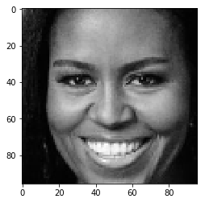

```python
plt.imshow(img[0][0],cmap='gray')   # Display 2D
```

```python
print (preds) # This is in torch and normalized
type(preds)
```

```
[[ 31.91837311  45.03163147]
 [ 32.14444733  49.43991852]
 [ 33.29781342  53.87453079]
 [ 34.07132721  57.98127365]
 [ 36.0992012   62.11851883]
 [ 38.45498657  66.17127228]
 [ 41.7785759   68.20689392]
 [ 45.88407135  70.56661224]
 [ 51.77573395  71.61331177]
 [ 57.55140305  70.28799438]
 [ 61.2011795   67.92386627]
 [ 64.06000519  64.96635437]
 [ 66.36424255  61.5667305 ]
 [ 68.26049805  57.23964691]
 [ 68.94345856  53.19948959]
 [ 69.46060181  49.3605957 ]
 [ 69.70620728  44.70311356]
 [ 36.46372604  40.61756134]
 [ 38.87702942  39.48457336]
 [ 41.35221863  38.97402954]
 [ 44.05982971  38.94151306]
 [ 46.12009048  39.54780579]
 [ 55.53476334  39.38409805]
 [ 57.52670288  39.0459404 ]
 [ 60.1037674   38.32487488]
 [ 62.9485054   39.02267838]
 [ 65.11042786  40.52859497]
 [ 50.77466202  44.68605423]
 [ 51.25164795  47.43872452]
 [ 50.99323654  50.53746033]
 [ 51.10580444  52.90823746]
 [ 48.12096405  54.7013092 ]
 [ 49.12936783  55.12967682]
 [ 51.69155502  55.54827881]
 [ 52.82741928  55.08000946]
 [ 54.40723419  54.81724548]
 [ 39.94078827  44.20928955]
 [ 41.72763824  43.72926331]
 [ 44.33873367  43.41846085]
 [ 45.86807632  44.70581818]
```

[output cut: 13 more lines]

```
 [ 55.58615494  58.99122238]
 [ 57.59950638  60.53695679]
 [ 55.64572144  62.19762802]
 [ 53.74912643  63.44667816]
 [ 51.50562668  63.50783539]
 [ 49.19062805  63.21915054]
 [ 47.21812439  62.39380264]
 [ 45.08415985  60.36713409]
 [ 49.35496902  59.92786407]
 [ 51.56791687  59.78071213]
 [ 53.36457062  60.0835228 ]
 [ 57.02178574  60.41282654]
 [ 52.76678085  61.29840088]
 [ 51.4199791   61.28553009]
 [ 49.61411285  61.35021973]]
```

```
numpy.ndarray
```

```python
# from torch.autograd import Variable
# preds = preds.detach().numpy()
# # undo normalization of keypoints
# preds = preds*50.0+100
```

[output not shown]

```python
preds   # It is now in numpy array format
```

```
array([[ 31.91837311,  45.03163147],
       [ 32.14444733,  49.43991852],
       [ 33.29781342,  53.87453079],
       [ 34.07132721,  57.98127365],
       [ 36.0992012 ,  62.11851883],
       [ 38.45498657,  66.17127228],
       [ 41.7785759 ,  68.20689392],
       [ 45.88407135,  70.56661224],
       [ 51.77573395,  71.61331177],
       [ 57.55140305,  70.28799438],
       [ 61.2011795 ,  67.92386627],
       [ 64.06000519,  64.96635437],
       [ 66.36424255,  61.5667305 ],
       [ 68.26049805,  57.23964691],
       [ 68.94345856,  53.19948959],
       [ 69.46060181,  49.3605957 ],
       [ 69.70620728,  44.70311356],
       [ 36.46372604,  40.61756134],
       [ 38.87702942,  39.48457336],
       [ 41.35221863,  38.97402954],
       [ 44.05982971,  38.94151306],
       [ 46.12009048,  39.54780579],
       [ 55.53476334,  39.38409805],
       [ 57.52670288,  39.0459404 ],
       [ 60.1037674 ,  38.32487488],
       [ 62.9485054 ,  39.02267838],
       [ 65.11042786,  40.52859497],
       [ 50.77466202,  44.68605423],
       [ 51.25164795,  47.43872452],
       [ 50.99323654,  50.53746033],
       [ 51.10580444,  52.90823746],
       [ 48.12096405,  54.7013092 ],
       [ 49.12936783,  55.12967682],
       [ 51.69155502,  55.54827881],
       [ 52.82741928,  55.08000946],
       [ 54.40723419,  54.81724548],
       [ 39.94078827,  44.20928955],
       [ 41.72763824,  43.72926331],
       [ 44.33873367,  43.41846085],
       [ 45.86807632,  44.70581818],
```

[output cut: 13 more lines]

```
       [ 55.58615494,  58.99122238],
       [ 57.59950638,  60.53695679],
       [ 55.64572144,  62.19762802],
       [ 53.74912643,  63.44667816],
       [ 51.50562668,  63.50783539],
       [ 49.19062805,  63.21915054],
       [ 47.21812439,  62.39380264],
       [ 45.08415985,  60.36713409],
       [ 49.35496902,  59.92786407],
       [ 51.56791687,  59.78071213],
       [ 53.36457062,  60.0835228 ],
       [ 57.02178574,  60.41282654],
       [ 52.76678085,  61.29840088],
       [ 51.4199791 ,  61.28553009],
       [ 49.61411285,  61.35021973]], dtype=float32)
```

```python
preds.shape  # all predicted keypoints from model in numpy array
```

```
(68, 2)
```

```python
preds.ndim
```

```
2
```

```python
preds[51][0]   # only x coordinate of 51st keypoint
```

```
51.454762
```

```python
preds[51][1] # only y co ordinate of the 51st keypoint
```

```
58.728058
```

```python
preds.shape
```

```
(68, 2)
```

```python
# helper function to display keypoints
def show_keypoints(image, key_pts):
    """Show image with keypoints"""
    plt.imshow(image)
    plt.scatter(key_pts[:,0], key_pts[:,1], s=20, marker='.', c='m')
```

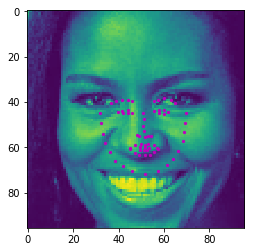

```python
show_keypoints(img[0][0], preds)
```

```python
# The keypoints ar sligtly off , the reson could be the dimension I chose (96,96) . My model had pretty good accuracy .
```